# searchnet: Network-Embedded Strategic Search Simulation in R

Manuscript prepared for the Journal of Statistical Software. searchnet 0.12.6.

Stephen Downing, University of Missouri

Abstract

The NK fitness landscape model is among the most widely used computational frameworks in strategy and organization theory, yet it treats the complexity parameter $K$ as exogenous, the landscape as fixed, and agents as isolated searchers. The R package **searchnet** addresses all three limitations by reformulating the NK model as a bipartite network of $M$ actors affiliating with $N$ components and embedding it within a Stochastic Actor-Oriented Model (SAOM). This reformulation reveals that the scalar $K$ is a special case of a four-dimensional coupled degree system—Expansiveness ($K_{AC}$), Popularity ($K_{CA}$), Sociality ($K_{AA}$), and Epistasis ($K_{CC}$)—whose dynamics are governed by actors’ forward-looking affiliation decisions rather than imposed by the modeler. The package provides an **R6**-based simulation engine built on **RSiena**, a clean functional API (`saomnk_env`, `saomnk_model`, `saomnk_run`), coupled degree visualization through the $\{K\}$-4 panel, utility decomposition diagnostics, exogenous shock infrastructure, and validation against the classical NK model. Worked illustrations demonstrate reproduction of classical NK search dynamics and quasi-experimental shock analysis. Benchmarks against raw **RSiena** quantify computational overhead and scalability. **searchnet** targets researchers in strategic management, organizational theory, innovation economics, and computational social science who study search, adaptation, and competitive dynamics on complex landscapes.

# 1 Introduction

The NK fitness landscape model (Kauffman and Levin 1987; Kauffman and Weinberger 1989) has become one of the most productive computational frameworks in strategic management and organization theory. Since Levinthal (1997) demonstrated that the NK model could illuminate the tension between exploration and exploitation on rugged performance landscapes, hundreds of studies have deployed it to investigate organizational adaptation, modular design, imitation, and competitive search (Baumann et al. 2019; Rivkin 2000; Siggelkow and Rivkin 2005).

The model’s appeal lies in its parsimony. Two parameters—$N$, the number of design choices or components, and $K$, the degree of epistatic interdependence among them—generate landscapes ranging from smooth single-peaked surfaces ($K = 0$) to highly rugged terrains ($K = N - 1$) populated by many local optima. This parsimony has also become the model’s principal liability. Four limitations recur across the literature.

First, the fitness landscape is **exogenous**: it is drawn once from a random distribution and does not respond to the positions that agents occupy. Firms competing on the same landscape experience identical payoff surfaces regardless of how many competitors share each component or how concentrated competitive attention has become. Second, **$K$ is a scalar** set by the modeler. In empirical organizational settings, interdependence is neither uniform nor fixed; some components are tightly coupled while others operate nearly independently, and coupling structures change as actors reconfigure their systems. Third, **multi-agent extensions** typically treat agents as independent searchers navigating the same landscape, ignoring the social and competitive structure through which firms observe, imitate, and crowd one another. Fourth, the NK model provides **no statistical framework** for parameter estimation from empirical data, making it difficult to discipline simulations with observed organizational behavior.

This paper introduces **searchnet**, an R package that addresses all four limitations simultaneously. The package reformulates the NK model as a bipartite network of $M$ actors (firms, agents, decision-makers) affiliating with $N$ components (technologies, resources, markets, design choices). By embedding this bipartite structure within a Stochastic Actor-Oriented Model (SAOM; Snijders 1996; Snijders et al. 2010), the search environment becomes a network data generation process whose topology—and therefore whose fitness landscape—co-evolves with actors’ affiliation decisions (Figure 1).

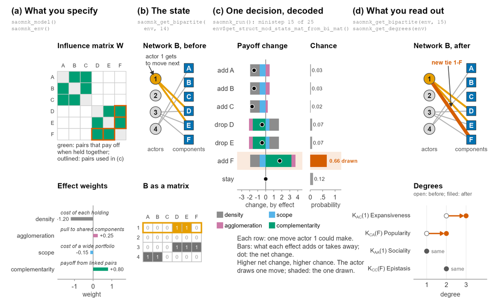

The **searchnet** workflow, one decision at a time. (a) The user specifies an influence matrix $W$ and effect weights. (b) The state is a bipartite network of actors (circles) and components (squares). (c) At a ministep the selected actor compares every single-tie change and staying put; each bar splits the change in its evaluation function by effect, and the logit probabilities follow. (d) The drawn move updates the network and the four $\{K\}$ degrees. All panels come from one seeded run of 4 actors and 6 components; the probabilities in (c) equal those recorded by **RSiena**. Generated by `paper/replication/make_figure1_mental_model.R`.

The package provides an **R6**-based simulation engine, a functional user API that abstracts away **RSiena**’s internal naming conventions, comprehensive visualization through the $\{K\}$-4 panel and 3D phase space, utility decomposition diagnostics, exogenous shock infrastructure for quasi-experimental designs, multi-wave Monte Carlo facilities, specification robustness tools, an interactive strategy game mode, and a classroom teaching module. Thirteen vignettes accompany the package: a quick-start introduction, theoretical foundations, a full simulation walkthrough with strategies and shocks, a computational experiment design guide, a causal inference tutorial, an NK validation guide, a Blume–Gibbs convergence tutorial, basin geometry, the Brock–Durlauf economic foundation, empirical calibration, the proof chain, formal verification with Lean 4, and a Professional Development Workshop curriculum.

# 2 Models

## 2.1 The NK fitness landscape

The NK model (Kauffman and Levin 1987; Kauffman and Weinberger 1989) characterizes performance landscapes with two parameters. A system of $N$ binary components (loci, design choices, technologies) generates $2^N$ possible configurations. Each component $d$ makes a fitness contribution $f_d$ that depends not only on its own state but also on the states of $K$ other components with which it is epistatically linked. Total fitness is the average contribution across all $N$ components. When $K = 0$, each component contributes independently and the landscape has a single global peak. As $K$ increases toward $N - 1$, the landscape becomes increasingly rugged, populated by exponentially many local optima that trap myopic searchers.

Levinthal (1997) introduced the NK model to management as a formalization of the exploration–exploitation trade-off: agents that search locally (single-bit mutations) on rugged landscapes quickly find nearby peaks but rarely discover the global optimum, while agents that search more broadly (multi-bit jumps) sacrifice short-run performance for a chance at higher peaks. This insight has been extended to organizational design (Siggelkow and Rivkin 2005), imitation (Rivkin 2000), modular architectures (Ethiraj and Levinthal 2004), and competitive interaction (Lenox et al. 2006).

## 2.2 Stochastic Actor-Oriented Models

Stochastic Actor-Oriented Models (Snijders 1996; Snijders et al. 2010) provide a continuous-time Markov model for the co-evolution of social networks and behavior. At each micro-step, a single actor is selected according to a rate function, evaluates the marginal utility of each possible tie change according to an objective function, and chooses probabilistically via a multinomial logit rule. The objective function takes the general form

$$\begin{equation}
\label{eq:saom-objective}
f_i(\mathbf{B}) = \sum_k \theta_k \, s_{ik}(\mathbf{B}),
\end{equation}$$

where $s_{ik}(\mathbf{B})$ are network statistics computed from the current network $\mathbf{B}$ and $\theta_k$ are parameters governing each actor’s preferences. The parameters $\theta_k$ can be estimated from observed panel data using the method of moments or maximum likelihood, implemented in the **RSiena** package (Snijders et al. 2025).

SAOMs are well established in sociology and political science for modeling friendship networks, advice networks, and inter-organizational partnerships. They have been extended to bipartite (two-mode) networks (Koskinen and Edling 2012), where the model governs actors’ affiliation decisions with respect to events, organizations, or other categorical entities. **searchnet** exploits this bipartite extension to model actors affiliating with components in a search environment.

### 2.2.1 Why SAOM over ERGM?

A natural question is why **searchnet** adopts the SAOM rather than the exponential random graph model (ERGM; Lusher et al. 2012) or its temporal extension (TERGM; Hanneke et al. 2010) as its network engine. The choice follows directly from the theoretical premise of the NK tradition. ERGMs characterize the equilibrium distribution of network configurations without specifying a generative decision process. An ERGM answers the question “what network structures are over-represented relative to chance?” but does not model *who* makes *which* decision *when*. For a framework whose purpose is to endogenize landscape ruggedness through actors’ strategic choices, this equilibrium focus omits precisely the mechanism of interest.

## 2.3 The implemented model

**Notation.** Throughout this paper we adopt the following notation. The bipartite incidence matrix is $\mathbf{B} \in \{0,1\}^{M \times N}$ with entries $b_{ij}$; the NK configuration vector for a single agent is $\mathbf{x} \in \{0,1\}^N$; the influence matrix is $\mathbf{E}$ (implemented in **RSiena** as the weight matrix $\mathbf{W}$ of the `XWX` effect); component payoff functions are $f_d$; and the logit precision parameter is $\beta > 0$.

A terminological note is warranted here, because the two ideas are routinely conflated. The matrix $\mathbf{E}$ is an *influence matrix* in the sense of Rivkin and Siggelkow (2007): it states which components interact and with what sign, and it is an *input* supplied by the analyst. *Epistasis* is the *consequence* – the dependence of one component’s fitness contribution on the states of others, which arises when a portfolio is evaluated through $\mathbf{E}$ as $\sum_{j \neq h} x_j x_h e_{hj}$ (the `XWX` statistic). The distinction matters in **searchnet** because a third quantity sits between the two. The component-component degree $K_{CC}$ records how far components are actually co-adopted at a given moment; it is computed from the realized affiliation matrix and does not read $\mathbf{E}$, yet it evolves as a *consequence* of $\mathbf{E}$, which drives the search that produces those affiliations. $K_{CC}$ therefore indexes the coupling epistasis acts through, generally differs from the influence structure that generated it, and is not itself a measure of the fitness consequence. Accordingly the package argument is named `influence_matrix`; `epistasis_matrix` is retained as a deprecated alias.

### 2.3.1 Bipartite network formulation

The classical NK model represents a system configuration as an $N$-dimensional binary vector $\mathbf{x} = (x_1, x_2, \ldots, x_N)$ where $x_j \in \{0, 1\}$. **searchnet** generalizes this by introducing $M$ actors, each of whom maintains an affiliation vector. The resulting system state is an $M \times N$ binary matrix $\mathbf{B}$, where $b_{ij} = 1$ indicates that actor $i$ affiliates with component $j$. This matrix is the incidence matrix of a bipartite network with actor nodes on one side and component nodes on the other.

The bipartite representation has three immediate consequences. First, it naturally accommodates **multiple agents** searching simultaneously: each row of $\mathbf{B}$ is an actor’s configuration, and actors’ configurations interact through shared columns. Second, it makes the **search environment endogenous**: the pattern of affiliations determines which components are coupled (via shared actors) and which actors are competitors (via shared components). Third, it provides the structural substrate for the SAOM engine: $\mathbf{B}$ becomes the dependent variable in an evolving bipartite network model.

### 2.3.2 The $\{K\}$ interpretive framework

The bipartite incidence matrix $\mathbf{B}$ generates four coupled degree statistics, each of which is individually a standard network measure but whose joint dynamics expose the mechanism through which micro-level search decisions produce macro-level landscape structure. Table 1 summarizes the four dimensions.

The $\{K\}$ coupled degree framework. Each dimension is a standard network statistic.

| Dimension | Symbol | Interpretation | Network measure |
| --- | --- | --- | --- |
| Expansiveness | $K_{AC}$ | Components per actor | Bipartite row degree |
| Popularity | $K_{CA}$ | Actors per component | Bipartite column degree |
| Sociality | $K_{AA}$ | Co-affiliating actors per actor | Actor projection degree (distinct partners) |
| Epistasis | $K_{CC}$ | Co-occurring components per component | Component projection degree (distinct partners) |

Table 2 translates the elements of the model into three business domains.

The elements of SAOM-NK in three business domains. Popularity is read only when a statistic distinguishes among holders, here by an actor attribute (reputation, certification, prestige).

| Model element | Technology portfolios | Retail assortments | Product design |
| --- | --- | --- | --- |
| Actor (row of $\mathbf{B}$) | firm | retail chain | design team |
| Component (column of $\mathbf{B}$) | technology class | product category | product module |
| Tie $b_{ij} = 1$ | firm patents in the class | chain carries the category | product includes the module |
| Influence matrix $\mathbf{W}$ | complementarity between classes | cross-selling between categories | interfaces between modules |
| Expansiveness ($K_{AC}$) | breadth of the technology portfolio | assortment breadth | modules per product |
| Epistasis ($K_{CC}$) | value of combining complementary classes | basket value of co-carried categories | fit of modules that share interfaces |
| Sociality ($K_{AA}$) | technological overlap with rivals | assortment overlap with competing chains | modules shared across teams |
| Popularity ($K_{CA}$) | classes held by high-reputation firms | categories carried by certified chains | modules used by prestigious products |
| Example effect (decision $\rightarrow$ outcome) | `outAct`: Expansiveness $\rightarrow$ Epistasis strength | `inPop`: Sociality $\rightarrow$ Sociality strength | `XWX`: Epistasis $\rightarrow$ Epistasis strength valued by $\mathbf{W}$ |

The classical NK parameter $K$ is the W-degree: the number of other components with a nonzero entry in a component’s row of the influence matrix $\mathbf{W}$. $K_{CC}$, the degree in the component projection, counts the components co-held with it by at least one actor; the two coincide only when a component’s co-held partners are exactly its partners in $\mathbf{W}$. In **searchnet**, $\mathbf{W}$ is set by the modeler, while $K_{CC}$ emerges from the bipartite network and co-evolves with the other three degree dimensions.

The analytical leverage of the $\{K\}$ framework comes from treating these four measures as a coupled system rather than examining any one in isolation. Because all four derive from the same incidence matrix $\mathbf{B}$, they are structurally linked. A change in Expansiveness ($K_{AC}$) mechanically alters Popularity ($K_{CA}$), which in turn reshapes both the actor co-membership network ($K_{AA}$) and the component co-occurrence network ($K_{CC}$). The projections are computed as:

$$\begin{align}
\mathbf{P}_{AA} &= \mathbf{B} \mathbf{B}^\top -
\text{diag}(\mathbf{B} \mathbf{B}^\top), \label{eq:proj-actor} \\
\mathbf{P}_{CC} &= \mathbf{B}^\top \mathbf{B} -
\text{diag}(\mathbf{B}^\top \mathbf{B}). \label{eq:proj-component}
\end{align}$$

The degree of actor $i$ in the actor projection $\mathbf{P}_{AA}$ is $K_{AA,i} = \sum_{h \neq i} \mathbf{1}[(\mathbf{B}\mathbf{B}^\top)_{ih} > 0]$, and symmetrically for $K_{CC,j}$ in the component projection. Analyzing any single measure in isolation obscures the cross-domain dependencies that link actor behavior to landscape topology.

The four statistics are individually well known in the bipartite network literature (Latapy et al. 2008; Borgatti and Everett 1997).

### 2.3.3 SAOM objective function specification

The SAOM objective function in **searchnet** governs actors’ affiliation decisions. At each micro-step, the selected actor $i$ evaluates the change in objective function value for each possible tie change (creating or dissolving an affiliation with one component) and selects the change that maximizes expected utility, subject to a stochastic error term drawn from the type I extreme value distribution.

The objective function takes the form of Equation [eq:saom-objective], with the following key statistics:

$$\begin{equation}
\label{eq:objective-classes}
\begin{aligned}
f_i(\mathbf{B}) ={}&
\underbrace{\color{clsComplementarity}\textstyle\sum_{\ell}\theta^{(\ell)}_{\text{epist}}
\sum_{j} b_{ij} \sum_{h \neq j} b_{ih}\, w^{(\ell)}_{hj}}_{
\substack{\text{\colorbox{clsComplementarity}{\textcolor{white}{\scriptsize\bfseries
complementarity}}\
\colorbox{black}{\textcolor{white}{\scriptsize\bfseries
$K_{CC}$}}}\\[1pt]
\text{\scriptsize Epistasis among held components}}}
\;+\;
\underbrace{\color{clsScope}\theta_{\text{dens}}\, b_{i+} +
\theta_{\text{scope}}\, b_{i+}^{2}}_{
\substack{\text{\colorbox{clsScope}{\textcolor{white}{\scriptsize\bfseries
scope}}\ \colorbox{black}{\textcolor{white}{\scriptsize\bfseries
decision $K_{AC}$ $\mid$ outcome $K_{CC}$}}}\\[1pt]
\text{\scriptsize breadth of holdings}}}
\\[4pt]
&+\;
\underbrace{\color{clsCrowding}\theta_{\text{pop}} \textstyle\sum_{j}
b_{ij}\, b_{+j}}_{
\substack{\text{\colorbox{clsCrowding}{\textcolor{white}{\scriptsize\bfseries
crowding}}\ \colorbox{black}{\textcolor{white}{\scriptsize\bfseries
$K_{AA}$}}}\\[1pt]
\text{\scriptsize crowding or agglomeration on shared
components}}}
\;+\;
\underbrace{\color{clsContact}\theta_{\text{close}}\,
\tfrac{1}{2}\textstyle\sum_{h \neq i} \binom{o_{ih}}{2}}_{
\substack{\text{\colorbox{clsContact}{\textcolor{white}{\scriptsize\bfseries
contact}}\ \colorbox{black}{\textcolor{white}{\scriptsize\bfseries
decision $K_{AA}$ $\mid$ outcome $K_{AA}$, $K_{CC}$}}}\\[1pt]
\text{\scriptsize repeated overlap between pairs of
actors}}}
\\[4pt]
&+\;
\underbrace{\color{clsImitation}\theta_{\text{imit}}
\textstyle\sum_{j} b_{ij}\,
\bigl(\mathrm{sim}_{ij} - \overline{\mathrm{sim}}\bigr)}_{
\substack{\text{\colorbox{clsImitation}{\textcolor{white}{\scriptsize\bfseries
imitation}}\ \colorbox{black}{\textcolor{white}{\scriptsize\bfseries
decision $K_{CA}$ $\mid$ outcome $K_{AA}$}}}\\[1pt]
\text{\scriptsize imitation of components held by similar
actors}}}
\;+\;
\underbrace{\color{clsCovariate}\theta_{\text{strat}}\,
b_{i+}\tilde{v}_i
+ \theta_{\text{value}} \textstyle\sum_{j} b_{ij}\, \tilde{c}_j}_{
\substack{\text{\colorbox{clsCovariate}{\textcolor{white}{\scriptsize\bfseries
covariates}}\ \colorbox{black}{\textcolor{white}{\scriptsize\bfseries
decision $K_{AC}$ $\mid$ outcome by effect}}}\\[1pt]
\text{\scriptsize observed heterogeneity of actors and
components}}}
\end{aligned}
\end{equation}$$

where $b_{i+} = \sum_j b_{ij}$ is actor $i$’s degree, $b_{+j} = \sum_h b_{hj}$ is component $j$’s degree (counting $i$), $o_{ih} = \sum_j b_{ij} b_{hj}$ is the overlap of actors $i$ and $h$, $\mathbf{W}^{(\ell)}$ is the $\ell$th influence matrix, $\tilde{v}$ and $\tilde{c}$ are actor and component covariates centered on their means (with `centered = TRUE`; the default, uncentered, statistic equals the centered one plus $\bar{v}\, b_{i+}$ or $\bar{c}\, b_{i+}$), and $\mathrm{sim}_{ij} = 1 - |v_i - \bar{v}_{-i,j}|/R_v$ compares $v_i$ with the mean $v$ of $j$’s other holders ($R_v$ the range of $v$; $\bar{v}_{-i,j}$ is the mean of $v$ when no other actor holds $j$; $\overline{\mathrm{sim}}$ the mean similarity over ordered pairs of distinct actors). Each term is the **RSiena** 1.5.0 two-mode statistic that **searchnet** computes; the co-holder performance similarity of `saomnk_coholder_similarity()` is a post hoc statistic and is not simulated.

SAOM objective function statistics in **searchnet**. Crowding reads as agglomeration when its coefficient is positive; the sign changes the reading, not the dimension. The two $\{K\}$ columns are those of `searchnet_effect_dimensions()`.

| Construct | RSiena name | Statistic $s_{ik}(\mathbf{B})$ | Decision dimension | Outcome dimension (target statistic) |
| --- | --- | --- | --- | --- |
| Scope (cost) | `density` | $\sum_j b_{ij}$ | Expansiveness | total ties |
| Crowding | `inPop` | $\sum_j b_{ij} \sum_{h} b_{hj}$ | Sociality | Sociality strength |
| Scope (breadth) | `outAct` | $\bigl(\sum_j b_{ij}\bigr)^{2}$ | Expansiveness | Epistasis strength |
| Complementarity | `XWX` | $\sum_j b_{ij} \sum_{h \neq j} b_{ih} w_{hj}$ | Epistasis | Epistasis strength valued by $\mathbf{W}$ |

The density effect serves as an intercept: a negative density parameter creates baseline sparsity pressure, preventing actors from affiliating with all components. The popularity effect (`inPop`) creates preferential attachment to components that many other actors already use. The scope effect (`outAct`) governs actors’ tendency to expand or contract the breadth of their affiliations. The epistasis effect (`XWX`) introduces exogenous component–component coupling via a modeler-supplied weight matrix $\mathbf{W}$ (denoted $\mathbf{E}$ in the formal proofs; see Section 6.1); actors derive utility from affiliating with components that are coupled to their existing affiliations.

Actor-level heterogeneity enters through constant covariates attached to the objective function. A covariate vector $\mathbf{v}$ (e.g., encoding strategic orientation) can modify the weight an actor places on popularity seeking (`inPopX`), scope expansion (`egoX`), or component characteristics (`altX`). This mechanism allows the modeler to assign distinct strategic profiles to different actors—for example, “exploiters” who preferentially attach to popular components and “explorers” who expand into uncrowded niches.

The simulation proceeds via **RSiena**’s continuous-time Markov chain algorithm. Actors are selected according to a rate function (by default, equal rates for all actors), and the selected actor evaluates all possible single-tie changes, choosing according to a multinomial logit rule:

$$\begin{equation}
\label{eq:choice}
P(b_{ij} \to 1 - b_{ij}) =
\frac{\exp\bigl(f_i(\mathbf{B}^{ij})\bigr)}
{\sum_{j'=0}^{N} \exp\bigl(f_i(\mathbf{B}^{ij'})\bigr)},
\end{equation}$$

where $\mathbf{B}^{ij}$ denotes the network configuration obtained by toggling actor $i$’s tie to component $j$, and $\mathbf{B}^{i0} = \mathbf{B}$ is the option to make no change. The `search_rsiena` method passes the full structure model to **RSiena**’s `siena07` function, which executes the continuous-time simulation internally.

For exogenous shocks, **searchnet** partitions the simulation timeline into proportional segments. At each segment boundary, the $\theta$ parameters are updated to new values specified by the shock schedule. The simulation then continues from the current network state with the modified objective function, preserving path dependence while allowing the researcher to model environmental discontinuities. This is equivalent to running sequential **RSiena** simulations where each wave’s initial state is the terminal state of the previous wave.

# 3 Software design

## 3.1 Architecture

**searchnet** is built on **R6** classes organized in a two-level inheritance hierarchy:

**`SaomNkRSienaBiEnv_base`**

Core environment initialization, bipartite matrix management, graph construction, projection computation, and utility helpers (toggle, Jaccard, existence checks). This base class manages the $M \times N$ incidence matrix, constructs the **RSiena** data objects, and provides low-level network operations.

**`SaomNkRSienaBiEnv`**

Full simulation engine inheriting from the base class, adding the `search_rsiena()` simulation method, chain statistics processing, $\{K\}$-4 degree computation, fitness landscape evaluation, shock handling, multi-wave experiment infrastructure, and the visualization interface.

Supporting modules provide separation of concerns:

- `saomnk-api.R`: User-facing functional API (`saomnk_env`, `saomnk_model`, `saomnk_run`) that wraps the R6 internals.
- `nk-classic.R`: A self-contained implementation of the classical NK model, used as an external reference for the reduction check of Section 5.1.
- `saomnk-experiments.R`: `SaoMNKexperiments` R6 class for batch Monte Carlo simulation management.
- `plot-*.R`: Ten modular plotting files (`plot-utility.R`, `plot-degrees.R`, `plot-exploration.R`, `plot-markets.R`, `plot-multiwave.R`, `plot-shocks.R`, `plot-snapshots.R`, `plot-phase-space.R`, `plot-forbearance.R`, `plot-geo.R`) containing visualization functions.
- `searchnet-game.R`: Strategy game mode providing an interactive game loop where a human player controls one firm and competes against AI opponents that follow SAOM-NK logit choice rules.
- `searchnet-teaching.R`: Classroom teaching module for Capsim-style strategy simulations supporting multiple industry presets, difficulty levels, and exogenous shocks.
- `utils.R`: Standalone helper functions.

## 3.2 Simulation as state-carrying periods

A call to `search_rsiena()` simulates one unit of model time, not a fixed number of ministeps. Each block of identical parameter rows is run as one unconditional **RSiena** period, started from the end network of the previous block, so the path carries its state across shocks and waves. The argument `iterations_per_actor` (`steps_per_actor` in `saomnk_run()`) sets the basic rate, that is, the expected number of opportunities per actor at zero rate effects; the realized number of ministeps is random. The engine stops if replaying a segment’s chain does not end at **RSiena**’s own end network.

## 3.3 Guards

Four guards target failures that leave no trace in the output. Every effect declared in a model must appear as included in the fitted **RSiena** effects object, so a misspelled or unmatched effect stops the run instead of disappearing. Covariate centering is stated: monadic covariates are uncentered unless the model says otherwise, and the centering applied is recorded. Each run records its provenance, including segment seeds and the realized ministep count. Seeds are drawn from hashed, namespaced streams, so neighboring seeds share no segment seed.

## 3.4 Ecosystem

### 3.4.1 Manim animation pipeline

For presentation and pedagogical purposes, **searchnet** exports simulation data in formats compatible with the **Manim** animation library (Manim Community 2022). The exported data includes per-step bipartite matrices, projection networks, degree trajectories, and utility decompositions. This pipeline is accessed through the `saomnk_export_manim()` method on the environment object and the `searchnet_export_phase_space()` function for phase space data.

### 3.4.2 Interactive features

**searchnet** includes two interactive modules that extend the simulation engine from a research tool to an instructional platform. The `searchnet_game_*` family of functions (five exported functions) provides an interactive game loop where a human player controls one firm and competes against AI opponents that follow the SAOM conditional-logit choice rule. The `searchnet_classroom_*` family (six exported functions) supports Capsim-style strategy simulations for classroom use.

# 4 Using **searchnet**

## 4.1 User API

A central design goal of **searchnet** is to provide a clean functional interface that shields users from the complexity of **RSiena**’s internal naming conventions and the R6 class hierarchy. The workflow follows three steps: environment creation, model specification, and simulation execution.

### 4.1.1 Step 1: Create the search environment

The `saomnk_env()` function initializes a bipartite search environment:

R> env <- saomnk_env(M = 8, N = 12, density = 0, seed = 42)

This creates a `SaomNkRSienaBiEnv` object representing 8 actors and 12 components, starting from an empty network (all actors unaffiliated). The `seed` argument ensures reproducibility of the initial network draw.

### 4.1.2 Step 2: Specify the structure model

The `saomnk_model()` function builds the SAOM objective function specification using intuitive parameter names:

R> ## Define a modular influence matrix: 4 blocks of 3 components R> K_matrix <- saomnk_block_diagonal(12, 4) R> R> ## Specify the model R> mod <- saomnk_model( + density = -0.5, # sparsity pressure + popularity = 0.2, # preferential attachment + scope = 0.1, # scope expansion + influence_matrix = K_matrix, + influence_weight = 0.05 + ) R> mod

SaoMNK Structure Model ———————- Effects on the bipartite network DV (3): density (density) theta = -0.5 [fixed] crowding (inPop) theta = 0.2 [fixed] scope (outAct) theta = 0.1 [fixed] Influence / dyadic covariates (1): complementarity (XWX) theta = 0.05 [fixed] [influence matrix W, 12 x 12]

Users never need to write internal references such as `"self$bipartite_rsienaDV"` or construct nested covariate lists manually. The function assembles the complete **RSiena** structure model internally. Actor strategy heterogeneity is specified through the `strategies` argument:

R> ## Heterogeneous actors: varying scope and popularity preferences R> mod_strat <- saomnk_model( + density = -0.3, + popularity = 0.2, + scope = 0.1, + influence_matrix = K_matrix, + influence_weight = 0.05, + strategies = list( + egoX = rep(c(-1, 0, 1, 0), length.out = 8), + inPopX = rep(c( 1, 0,-1, 0), length.out = 8) + ) + )

### 4.1.3 Step 3: Run the simulation

The `saomnk_run()` function executes the SAOM simulation:

R> saomnk_run(env, mod, steps_per_actor = 30, seed = 12345)

The function passes the structure model to the internal `search_rsiena()` method, runs the continuous-time SAOM simulation via **RSiena**, extracts chain statistics, and computes the $\{K\}$-4 degree trajectories. The `env` object is modified in place (standard R6 semantics) and returned invisibly.

## 4.2 Mapping RSiena effects to strategic search concepts

The preceding objective function uses **RSiena** effect names that are standard in social network analysis but may be unfamiliar to strategy researchers. Table 4 provides a systematic mapping between RSiena effects available in **searchnet** and their strategic search interpretations. Each effect’s parameter symbol links it to the corresponding $\{K\}$ dimension introduced in Section 2.3.2, enabling researchers to translate between the network estimation vocabulary and the strategy-theoretic language of scope, complementarity, and imitation.

Mapping RSiena effects to strategic search concepts. Parameters correspond to the SAOM objective function (Equation [eq:saom-objective]). The two $\{K\}$ columns give each effect’s decision dimension (its change statistic) and outcome dimension (its target statistic) (`searchnet_effect_dimensions()`).

| RSiena Effect | Parameter | Decision dimension | Outcome dimension (target statistic) | Strategy Concept | Interpretation |
| --- | --- | --- | --- | --- | --- |
| `density` | $\theta_{\text{dens}}$ | Expansiveness | total ties | Scope cost | Negative = costly to hold activities; controls portfolio breadth |
| `outAct` | $\theta_{\text{scope}}$ | Expansiveness | Epistasis strength | Diminishing returns | Quadratic penalty on actor degree (scope) |
| `inPop` | $\theta_{\text{pop}}$ | Sociality | Sociality strength | Crowding / agglomeration | Negative = avoid components other actors hold (crowding); positive = agglomeration |
| `XWX` | $\theta_{\text{epist}}$ | Epistasis | Epistasis strength valued by $\mathbf{W}$ | Complementarity / synergy | Reward for holding epistatically linked components |
| `simEgoInDist2` | $\theta_{\text{imit}}$ | Popularity | Sociality strength, similarity-weighted | Imitation / herding | Positive = prefer components held by covariate-similar actors (needs an actor covariate) |
| `egoX` | $\theta_{\text{strat}}$ | Expansiveness | Expansiveness, attribute-weighted | Strategy heterogeneity | Actor-level covariate modifying search behavior |
| `altX` | $\theta_{\text{value}}$ | Expansiveness | Popularity, attribute-weighted | Component value | Exogenous activity-level payoff differences |
| `cycle4` | $\theta_{\text{close}}$ | Sociality | Sociality and Epistasis | Contact | Repeated overlap between pairs of actors (four-cycles) |

The table makes explicit the division of labor among effects. The first four rows—`density`, `outAct`, `inPop`, and `XWX`—are the workhorses of most **searchnet** specifications. Together they endogenize the four $\{K\}$ dimensions: scope cost sets the baseline, `outAct` introduces diminishing returns to breadth, `inPop` sets crowding on shared components (agglomeration when positive), and `XWX` rewards configurations that exploit exogenous complementarities. The remaining effects allow the researcher to layer on additional mechanisms: imitation (`simEgoInDist2`, which requires an actor covariate) draws actors toward components held by actors similar on that covariate, actor and component covariates (`egoX`, `altX`) introduce heterogeneity, and `cycle4` captures repeated overlap between pairs of actors (contact). By selecting which effects to include and setting their parameter values, the researcher controls which strategic mechanisms are active in a given simulation—a design choice whose consequences can be audited with the diagnostic tools described in Section 5.1.

## 4.3 Visualization

**searchnet** provides a comprehensive visualization toolkit organized around four analytical perspectives.

### 4.3.1 The $\{K\}$-4 panel

The signature visualization is the coupled degree panel, which displays all four $\{K\}$ dimensions over the simulation timeline:

R> saomnk_plot_k4(env, smooth = 0.3)

[figure not shown]

The $\{K\}$-4 coupled degree panel showing the degrees of Expansiveness ($K_{AC}$), Popularity ($K_{CA}$), Sociality ($K_{AA}$), and Epistasis ($K_{CC}$) over 256 simulation micro-steps. Each point is a single actor or component at one ministep; the heavy line is the LOESS-smoothed mean degree.

### 4.3.3 Predefined counterfactual scenarios

The package includes six predefined scenarios:

1. **Density shock**: Exogenous reduction in network density (e.g., deregulation increasing market access).
2. **Double closure**: Doubling the transitive triad parameter to simulate increased alliance clustering.
3. **Popularity concentration**: Amplifying preferential attachment to model winner-take-all dynamics.
4. **Scope expansion**: Increasing actor scope to simulate diversification strategies.
5. **Epistasis rewiring**: Modifying the component influence matrix to simulate modular-to-integral design shifts.
6. **Attribute homophily**: Strengthening similarity-based affiliation to model industry convergence.

Each scenario modifies the calibrated parameter vector and re-runs the simulation, yielding a comparison structure with changes in all four $\{K\}$ dimensions, basin geometry, and fitness distributions. For a full worked example see `vignette("saomnk-calibration", package = "searchnet")`.

# 5 Illustrations

## 5.1 Validation against the classical NK model

A software paper should demonstrate that its engine reproduces the model it generalizes. **searchnet** ships a self-contained implementation of the classical Kauffman NK model, independent of **RSiena** and of the SaoMNK engine, and uses it as an external reference.

### 5.1.1 A conventional NK implementation

`nk_landscape()` constructs a Kauffman landscape by exhaustive enumeration of all $2^N$ configurations. Each locus $i$ contributes $f_i(b_i, b_{\Omega(i)})$, drawn i.i.d. $U(0,1)$ for every distinct pattern of its epistatic neighborhood $\Omega(i)$; total fitness is the mean of the $N$ contributions. Three neighborhood topologies are supported: `"adjacent"` (Kauffman’s ring model), `"random"`, and `"block"` (near-decomposable). Companion functions provide adaptive walks (`nk_walk()`, with steepest-ascent, random-ascent, and random-improving rules), exhaustive local optimum enumeration (`nk_local_optima()`), and the canonical ruggedness sweep (`nk_sweep_K()`).

These functions are useful in their own right, but their role here is to supply a reference implementation that shares no code with the SAOM engine.

### 5.1.2 Verifying the reduction

Property 1 (Section 6.1) states that the classical NK model is the $M = 1$, $\beta \rightarrow \infty$ special case of SaoMNK. `nk_to_saomnk()` emits the environment and structure-model settings that place a single-actor SaoMNK environment on a supplied NK landscape, making the reduction constructive rather than merely asserted.

`nk_verify_reduction()` then checks the construction. It exploits the defining property of the NK model: contribution $f_i$ depends only on the loci in $\Omega(i)$, so any two configurations sharing the same neighborhood pattern must carry identical $f_i$. Rebuilding each locus’s payoff table keyed by that pattern and recomputing fitness must return the original values exactly. A non-zero difference would indicate an indexing or bit-ordering error in landscape construction.

R> nk <- nk_landscape(N = 10, K = 3, seed = 42) R> nk_verify_reduction(N = 10, K = 3, seed = 42)

NK reduction check: N=10, K=3, model="adjacent" configurations : 1,024 max |difference| : 0.00e+00 result : PASS

The check passes at machine precision (maximum absolute difference $0.00 \times 10^{0}$) across the $(N, K)$ combinations exercised in the test suite. Configuration encoding is most-significant-bit-first throughout and is covered by exhaustive round-trip tests for $N = 1, \ldots, 12$; this guards a class of bit-ordering error that is easy to introduce and silent when it occurs.

### 5.1.3 Recovering classical results

The implementation reproduces the standard qualitative findings of the NK literature. With $K = 0$ the landscape is single-peaked, and a steepest-ascent walk from any starting configuration reaches the global optimum. As $K$ rises the number of local optima grows, approaching the familiar $2^N / (K+1)$ scaling, adaptive walks terminate sooner, and terminal fitness falls (Kauffman and Levin 1987; Kauffman and Weinberger 1989; Levinthal 1997). `nk_sweep_K()` reproduces this experiment directly.

### 5.1.4 Reproducing Levinthal (1997)

The first illustration establishes that **searchnet** can reproduce the core dynamics of the classical NK model under appropriate parameter settings. We configure an environment with no endogenous network effects, leaving only the exogenous influence matrix active. Setting both `popularity` and `scope` to zero removes every term through which one actor’s state can enter another’s objective function, so the actors search *independently*: the model reduces to parallel single-searcher processes on a landscape whose ruggedness is determined solely by the exogenous coupling matrix, which is the functional equivalent of the classical NK search process. We use $M = 2$ rather than $M = 1$ because `search_rsiena()` requires at least two actors — **RSiena**’s `sienaDataCreate()` does not accept a single-actor bipartite network. For genuinely single-actor work the landscape methods (`compute_fitness_landscape`, `verify_nk_equivalence`) accept $M = 1$ directly, and Section 5.1 uses them for exactly that.

R> ## Two INDEPENDENT searchers (popularity = scope = 0 removes all R> ## coupling), 12 components, empty start. M >= 2 is required by R> ## RSiena’s bipartite data constructor; with the interaction terms R> ## zeroed the actors do not influence one another, so each is a R> ## classical NK searcher. R> env_nk <- saomnk_env(M = 2, N = 12, density = 0, seed = 1234) R> R> ## Block-diagonal epistasis: 3 modules of 4 components (K 3) R> K_levinthal <- saomnk_block_diagonal(12, 3) R> R> ## Only epistasis active; no endogenous effects R> mod_nk <- saomnk_model( + density = -0.3, + popularity = 0, + scope = 0, + influence_matrix = K_levinthal, + influence_weight = 0.15 + ) R> R> saomnk_run(env_nk, mod_nk, steps_per_actor = 100, seed = 42)

Under this parameterization, the agent’s search trajectory exhibits the signature features of NK dynamics: rapid initial improvement as the agent discovers complementary component clusters, followed by convergence to a local optimum where no single-component change improves utility. The K-4 panel reduces to the $K_{AC}$ trajectory (Expansiveness) and the $K_{CC}$ trajectory (Epistasis), with the latter reflecting the fixed block-diagonal structure; the $K_{CA}$ and $K_{AA}$ dimensions are flat by construction, since nothing couples the two searchers.

[figure not shown]

Expansiveness ($K_{AC}$) trajectory for independent agents searching on a block-diagonal epistasis landscape. The trajectory shows rapid scope expansion followed by stabilization—the SAOM equivalent of convergence to a local optimum on a rugged NK landscape.

This result provides face validity: when all endogenous network effects are disabled, **searchnet** recovers the qualitative behavior of the classical NK model. The landscape is effectively exogenous (determined by the fixed $\mathbf{W}$ matrix), search is local (single-tie changes), and convergence reflects the trapping property of rugged landscapes.

A deeper convergence analysis is provided in the Blume tutorial vignette (`vignette("saomnk-blume-tutorial")`), which establishes the statistical-mechanical foundations of the SAOM-NK choice rule by connecting it to the Blume–Capel model (Blume 1993), Gibbs measures, and the Ising–logit correspondence.

## 5.2 Coupled degree dynamics

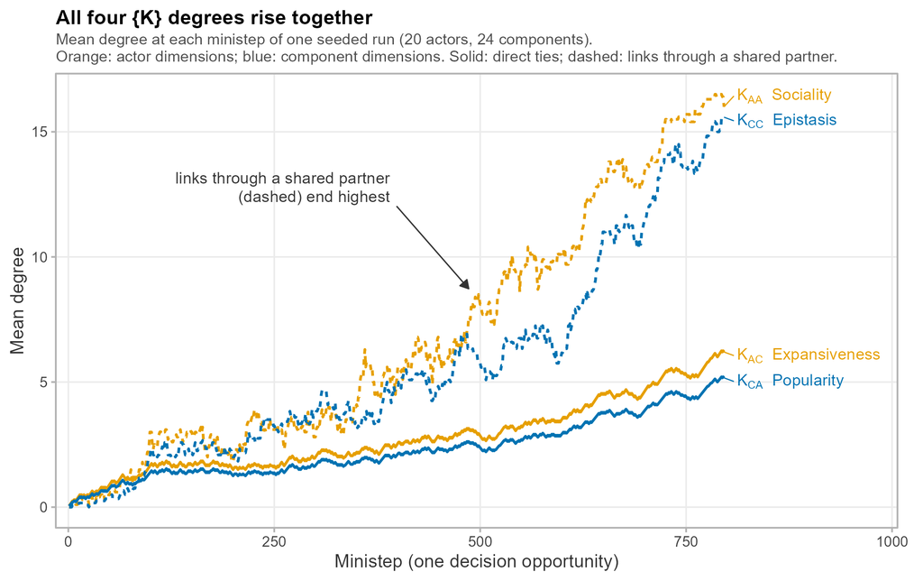

Simulated demonstration that the four $\{K\}$ dimensions move as a coupled system. A single seeded run of 20 actors over 24 components with a block-diagonal influence matrix, plotted by **searchnet** from the simulated chain. Because all four degrees are read off the same bipartite incidence matrix, they rise together from an empty start; the smallest pairwise correlation across the four series is $0.98$. This panel is simulated output, not empirical data. Generated by `paper/replication/make_k_system_figures.R`.

## 5.3 Ergodicity: forgetting the initial condition

Property 4 (Section 6.1) asserts that the chain’s stationary distribution is unique and independent of where the simulation starts. That property is easy to illustrate badly. Running the model once from a sparse start and once from a dense start, then observing that the two final densities are close, establishes very little: no threshold was declared in advance, a single run per arm supplies no sampling distribution, and—most importantly—an ergodic chain forgets its initial condition *at a rate*, which a pair of endpoints discards.

**searchnet** therefore ships the demonstration as a measurement. `searchnet_ergodicity_sweep()` runs the same fixed-coefficient model from two contrasting starting densities across a range of chain lengths, with independent replicates at each, and reports how fast the between-arm gap decays:

R> erg <- searchnet_ergodicity_sweep( + M = 12, N = 15, start_densities = c(0.1, 0.8), + run_lengths = c(15, 30, 60, 120, 240), + replicates = 10, equivalence_margin = 0.05, seed = 42 + ) R> erg

Ergodicity sweep (Property 4: independence from initial conditions) 12 actors x 15 components (180 cells; one tie = 0.0056 density) arms starting at 0.10 and 0.80, 10 replicates each

run length mean(lo) mean(hi) gap 15 0.7533 0.9478 0.1944 30 0.9478 0.9594 0.0117 60 0.9544 0.9583 0.0039 120 0.9594 0.9494 0.0100 240 0.9556 0.9583 0.0028

initial gap 0.7000 –> final gap 0.0028 (99.6 Monte Carlo floor (10 replicates): 0.0047 decay above the floor: log(gap) -1.24 * log(iterations), R^2 = 0.617 (fit on 3 point(s); 60, 240 excluded as at-or-below the floor)

TOST at 240 iterations, margin +/- 0.050, 90 EQUIVALENT – the arms are statistically indistinguishable at the declared margin. The chain has forgotten where it started.

R> plot(erg)

[figure not shown]

Independence from initial conditions, measured rather than asserted. (a) Two arms starting at density 0.10 and 0.80 converge as run length grows; points are replicates. (b) The between-arm gap decays as a power of run length on log–log axes. The dashed line is the declared equivalence margin; the shaded band is the Monte Carlo floor, below which the measured gap reflects replicate noise rather than mixing, and which is excluded from the fitted slope.

Two arms separated by a starting gap of 0.70 close to within 0.01 by 240 iterations per actor, a collapse of more than 99%, and the gap decays as a power of run length with slope near $-1$ and $R^2 = 0.617$. The verdict is computed rather than printed: at the longest run length the arms are compared by a two-one-sided-tests equivalence procedure against a margin fixed in the call, so the function is able to report *non*-equivalence. This is what makes the sweep evidence rather than illustration.

Two details matter for anyone reproducing this. The Monte Carlo floor is drawn explicitly, because once the arms are genuinely equivalent the measured gap settles at the expected difference between two sample means from the same distribution rather than falling to zero; fitting a decay slope through those points would overstate the rate. And the grid is sized so that density has resolution: on the 4 $\times$ 5 grid used in earlier versions of this demonstration a single tie moved the density by 0.05, which is coarser than any equivalence margin worth declaring.

The vignette derives detailed balance with respect to the Gibbs distribution for single-flip logit revision. The multinomial ministep simulated here has no general Gibbs form for $M > 1$, so the convergence measured here rests on ergodicity alone.

## 5.4 Exogenous shocks

This illustration demonstrates **searchnet**’s shock infrastructure. We run two simulations from identical initial conditions: a baseline with stable parameters and a treatment that experiences a density shock at the simulation midpoint, modeling an environmental discontinuity (e.g., a regulatory change that increases the cost of broad scope).

R> env_base <- saomnk_env(M = 6, N = 8, density = 0, seed = 42) R> env_shock <- saomnk_env(M = 6, N = 8, density = 0, seed = 42) R> R> K_small <- saomnk_block_diagonal(8, 2) R> mod_base <- saomnk_model( + density = -0.5, + influence_matrix = K_small, + influence_weight = 0.5 + ) R> R> ## Baseline: no shocks R> saomnk_run(env_base, mod_base, steps_per_actor = 80, seed = 12345) R> R> ## Shocked: density drops from -0.5 to -2.0 at midpoint R> shock_baseline <- saomnk_shock("density", parameter = -0.5, + portion = 1) R> shock_event <- saomnk_shock("density", parameter = -2.0, + portion = 1) R> R> saomnk_run(env_shock, mod_base, steps_per_actor = 80, seed = 12345, + shocks = list(shock_baseline, shock_event))

R> ## Display baseline K-4 panel R> saomnk_plot_k4(env_base, smooth = 0.3)

[figure not shown]

Baseline $\{K\}$-4 panel (this figure) and the shocked run (next figure). The density shock at the midpoint (dashed vertical line) creates a visible structural break in all four degree trajectories. Increased sparsity pressure compresses actor scope, which propagates through component popularity, actor sociality, and component epistasis.

R> ## Display shocked K-4 panel R> saomnk_plot_k4(env_shock, smooth = 0.3)

[figure not shown]

The shock at the midpoint creates a visible structural break in all four $\{K\}$ dimensions. The increased density penalty (from $-0.5$ to $-2.0$) intensifies sparsity pressure, causing actors to shed affiliations. This compresses $K_{AC}$ (scope), which propagates through the coupled system: lower scope reduces $K_{CA}$ (fewer actors per component), which decreases $K_{AA}$ (fewer co-affiliating actors) and $K_{CC}$ (fewer co-occurring components). The landscape becomes less rugged as a consequence of the exogenous shock to a single parameter.

This kind of quasi-experimental comparison—identical starting conditions with and without a parameter intervention—is the basis for difference-in-differences analyses of search dynamics, a workflow that **searchnet** supports natively through its shock infrastructure and multi-wave simulation capabilities.

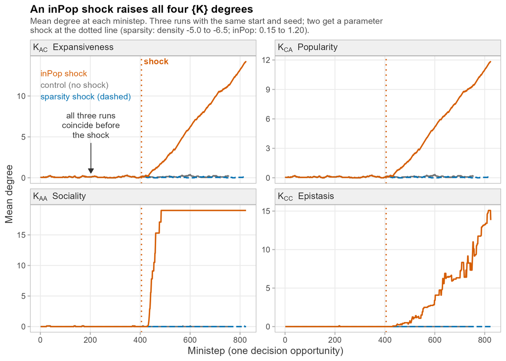

Simulated demonstration that a shock relocates the coupled system. Three seeded arms share starting conditions and the random seed, so their trajectories coincide exactly until the intervention at the dotted line. A sparsity shock (density $-5.0 \rightarrow -6.5$) leaves every dimension near zero, as in the control; an `inPop` shock ($0.15 \rightarrow 1.20$) moves every dimension up. Terminal mean $K_{CC}$ is $0.0$, $0.0$ and $13.8$ in the sparsity, control and `inPop` arms. This panel is simulated output, not empirical data. Generated by `paper/replication/make_k_system_figures.R`.

## 5.5 From shocks to causal inference

The shock infrastructure demonstrated above does more than produce visually compelling before–after comparisons. Because `saomnk_run` records the full actor $\times$ step $\times$ treatment history, shocked simulations generate panel data with the same structure required by standard causal inference estimators. The $\theta$-shock partitions the simulation timeline into a pre-treatment period (steps before the shock) and a post-treatment period (steps after), while the researcher controls which actors are treated.

**searchnet** provides helper functions that extract this panel structure and interface with the **did** package (Callaway and Sant’Anna 2021), which implements the Callaway and Sant’Anna (2021) estimator for difference-in-differences with staggered treatment adoption. The workflow proceeds in three steps: extract a panel data frame from the shocked and unshocked environments, estimate group–time average treatment effects, and visualize the results.

R> did_result <- searchnet_did(panel) R> did::aggte(did_result, type = "simple")

Call: did::aggte(MP = did_result, type = "simple")

Reference: Callaway, Brantly and Pedro H.C. Sant’Anna. "Difference-in-Differences with Multiple Time Periods." Journal of Econometrics, Vol. 225, No. 2, pp. 200-230, 2021. <https://doi.org/10.1016/j.jeconom.2020.12.001>, <https://arxiv.org/abs/1803.09015>

ATT Std. Error [ 95 -9.767 1.296 -12.31 -7.227 *

— Signif. codes: ‘*’ confidence band does not cover 0

Control Group: Never Treated, Anticipation Periods: 0 Estimation Method: Doubly Robust

R> searchnet_causal_plot(did_result)

[figure not shown]

Difference-in-differences estimates from shocked and unshocked runs with the same start and seed. The plot shows event-time average treatment effects on actor utility, with 95% simultaneous confidence intervals.

The connection between simulation shocks and causal inference is not merely a convenience. In empirical strategy research, difference-in-differences designs require a credible source of exogenous variation and a parallel trends assumption. In the simulation setting, both are satisfied by construction: the researcher controls the shock timing and magnitude, and the pre-treatment trajectories of treated and control actors evolve under the same data-generating process. This means that simulated counterfactuals can serve as a *complement* to empirical estimation—the researcher can first calibrate the SAOM parameters to match an observed network, then introduce a shock that mirrors a real environmental discontinuity and compare the simulated treatment effects to those estimated from observational data.

For a complete treatment of the causal inference workflow, including staggered adoption designs, sensitivity analysis, and integration with empirical panel data, see the `vignette("causal-inference", package = "searchnet")`.

## 5.6 Basin geometry

The **searchnet** package provides tools for analyzing the geometry of fitness landscape basins—regions of the configuration space that converge to local optima under gradient ascent. Basin analysis quantifies two fundamental properties of competitive positions.

**Basin depth** measures the fitness gap between a local peak and its basin boundary:
$$\begin{equation}
\label{eq:basin-depth}
\text{Depth}(p) = F(p) - \frac{1}{|\partial B(p)|} \sum_{x \in
\partial B(p)} F(x),
\end{equation}$$
where $\partial B(p)$ is the boundary of basin $B(p)$.

**Basin width** measures the mean Hamming distance of basin members from the peak:
$$\begin{equation}
\label{eq:basin-width}
\text{Width}(p) = \frac{1}{|B(p)|} \sum_{x \in B(p)} d_H(x, p).
\end{equation}$$
Width captures strategic flexibility—the number of distinct configurations that converge to the same competitive outcome.

### 5.6.1 Computing basin geometry

The `compute_fitness_landscape()` method enumerates configurations and identifies local peaks:

R> env <- SaomNkRSienaBiEnv$new(list(M = 8, N = 8, BI_PROB = 0.4, + rand_seed = 42)) R> env$compute_fitness_landscape(n_landscapes = 1) R> R> ## Extract landscape data R> landscape <- env$fitness_landscape[1,,] R> N <- env$N R> configs <- landscape[, 1:N] R> fitness <- landscape[, 2*N + 1] R> is_peak <- landscape[, 2*N + 2] == 1

Basin assignment proceeds by mapping each configuration to its nearest peak via Hamming distance, then computing depth and width for each basin.

### 5.6.2 Landscape erosion under shocks

When shocks modify the influence matrix $\mathbf{W}$, the landscape reshapes. The **searchnet** shock infrastructure enables systematic measurement of **landscape erosion**:
$$\begin{equation}
\label{eq:erosion}
\text{Erosion}(p) = \text{Depth}_{\mathbf{W}_0}(p) -
\text{Depth}_{\mathbf{W}_1}(p).
\end{equation}$$

The `shock_theta_matrix()` function implements regime changes at designated iterations, enabling pre- vs. post-shock basin comparison within a single simulation run.

## 5.7 Firm and industry effects

We illustrate the package with a worked application built on simulated data. It states a problematization, the specification that answers it, and a takeaway, so that a reader can find the closest case to their own problem.

| Application | Domain | Mode of use | $\{K\}$ dimensions driven |
| --- | --- | --- | --- |
| Firm vs. industry effects | Variance decomposition | Simulation engine | $K_{AC}$, $K_{CA}$, $K_{CC}$ |

Two dimensions deserve a warning that applies throughout. First, $K_{CA}$ moves through `inPop`, whose target statistic is Sociality strength, the second moment of $K_{CA}$, not through similarity-weighted imitation. With an actor covariate, **RSiena** 1.5.0 does define `simEgoInDist2` for a bipartite dependent variable, but **searchnet**’s co-holder statistic, `saomnk_coholder_similarity()`, is a different quantity. **searchnet** supplies it for post-hoc computation but cannot make it a simulable evaluation term, and the application below does not use it as one. Second, $K_{AA}$ is a degree in the actor *projection*, so it is frequently measured as an outcome rather than entered as an effect; the table records what is driven, not what is reported.

The variance-decomposition literature asks whether firm or industry effects explain more of the variance in profitability. If firms are competitively coupled, the two are not separable in principle, and a simulation in which the data-generating process is known can show what a decomposition recovers.

This application is the cleanest illustration of the minimal functional pipeline, and we present it as such:

R> env <- saomnk_env(M = M, N = N, density = 0.2, seed = seed) R> ## arch_type: "modular", "hierarchical" or "random" R> K <- make_influence_matrix(N, arch_type) R> R> mod <- saomnk_model(density = -0.5, popularity = coupling, + scope = 0.05, influence_matrix = K, + influence_weight = 0.1) R> R> saomnk_run(env, mod, steps_per_actor = 15L, seed = seed + 1L) R> bi_mat <- saomnk_get_bipartite(env)

Coupling strength enters through `popularity`, sweeping $\{0, 0.1, 0.3, 0.5, 0.8\}$ across three architectures. We report the pipeline, not a bias estimate: in the present implementation the “true” effects are re-derived from the same realized performance the estimator sees, so the recovered bias is zero by construction. Establishing a bias requires taking the truth from the generating parameters instead, and that work is ongoing. We state this because a software paper is the wrong place to launder an unfinished result, and because the pipeline above is genuinely the shortest path from a specification to a simulated bipartite panel.

**Takeaway.** The shortest path from specification to simulated panel is four calls. The vignette also shows what a simulation cannot do for you: if the “true” effects are re-derived from the same realized outcome the estimator sees, recovered bias is zero by construction, whatever the coupling.

### 5.7.1 Failure modes inherited from **RSiena**

Because **searchnet** delegates estimation to `siena07`, it inherits that estimator’s failure modes, and users should know two of them.

The first is provable. Under method-of-moments estimation, no effect whose observed statistic lies exactly on the boundary of its attainable support can converge: the estimate diverges as $\theta \to \pm\infty$. In a *balanced* bipartite panel every actor holds at least one component in every wave, so the isolate count is exactly zero and `outTrunc(1)` is exactly $M$ — both saturated. The screen is one line — compute $(\text{observed} - \text{lo}) / (\text{hi} - \text{lo})$ and refuse exactly $0$ or $1$ — and it costs nothing to run before estimating. We note that a stronger version of this claim, covering *near*-boundary statistics, was tested and refuted: only exact saturation disqualifies.

The second is a silent-failure pattern rather than a theorem, and it bit this package. `RSiena::includeEffects` matches effect names by non-standard evaluation, so passing a name held in a variable silently selects nothing. A version of **searchnet** passed `shortName = eff$effect` into `...`, where the unevaluated expression was deparsed and no effect matched; because the call was wrapped in `tryCatch(..., error = function(e) warning(...))`, the simulation continued with the covariate effect *absent*. Every actor-covariate effect was affected, so results labeled “heterogeneous strategies” were in fact homogeneous-actor results. The package now ships a regression test asserting that every effect declared in a `structure_model` appears with `include == TRUE` in the fitted effects object. The design lesson generalizes beyond this package: `tryCatch`-to-warning is right for interactive exploration and wrong for a simulation engine whose output gets published.

# 6 Verification and validation

## 6.1 Formal properties

We state the properties here; complete proofs with all lemmas are provided in `inst/proofs/` in the package (access via `searchnet_proof()`).

**Property 1 (reduction to NK).**

The standard NK model is a degenerate special case of the SAOM-NK model. Specifically, the NK landscape and its adaptive walk are recovered exactly under five restrictions: (R1) $M = 1$ (single actor); (R2) $\mathbf{E} = \mathbf{A}$ (SAOM-NK influence matrix equals the NK influence matrix); (R3) $\boldsymbol{\theta} = \mathbf{0}$ (all SAOM parameters zero); (R4) $\beta \to \infty$ (deterministic greedy choice); (R5) uniform component selection probability.  
Test: `tests/testthat/test-nk-equivalence.R`, `tests/testthat/test-nk-classic.R`.  
Lean: `SaomNK.utility_eq_nkFitness`, `SaomNK.logitProb_tendsto_one`, `SaomNK.stayProb_tendsto_one`.

**Property 2 (generalization of NK).**

SAOM-NK strictly generalizes the NK model along three dimensions: (a) multiple actors ($M > 1$), who affect one another only through a cross-actor effect such as `inPop`, that is, through (b), (b) endogenous landscape co-evolution through SAOM network statistics, and (c) bounded rationality with tunable search precision ($\beta \in (0, \infty)$). The coupled degree vector $\{K\}= (K_{AC}, K_{CA}, K_{AA}, K_{CC})$ spans a strictly larger class of fitness landscapes than the scalar $K$ parameterization. The classical NK model is recovered as a proper special case: NK $\subsetneq$ SAOM-NK.  
Test: `tests/testthat/test-property-2.R`.  
Lean: `SaomNK.card_config_gt`, `SaomNK.CoreSpec.landscape_endogeneity`, `SaomNK.logitProb_pos`.

**Property 3 (approximation of NK landscapes).**

For any NK landscape $(N, K, \mathbf{A}, \{f_d\}_{d=1}^N)$, there exists a parameterization of the SAOM-NK model that reproduces the NK payoff structure to arbitrary precision. It holds exactly by (a) constructive existence via dummy covariates. (b) Actor heterogeneity substitution, with covariates linear in the actor’s own row, reproduces only $K = 0$ landscapes; (c) universal approximation via mixed logit is not checked numerically.  
Test: `tests/testthat/test-property-3.R`.  
Lean: `SaomNK.nkTermFull_in_dummy_span`.

**Property 4 (SAOM–QRE correspondence).**

The SAOM multinomial logit choice rule (Equation [eq:choice]) is isomorphic to a quantal response equilibrium (QRE) in the bipartite affiliation game, establishing a game-theoretic foundation for the statistical model. The resulting chain has a unique stationary law; its Gibbs form and zero-noise selection of potential maximizers are guaranteed for single-flip logit revision, not for this multinomial rule when $M > 1$.  
Test: `tests/testthat/test-searchnet-ergodicity.R`, `tests/testthat/test-potential-cycles.R`, `tests/testthat/test-lean.R`.  
Lean: `SaomNK.Spec.exact_potential`, `SaomNK.detailed_balance_of_potential`, `SaomNK.global_balance_of_potential`, `SaomNK.reachable`.

**Property 5 (Brock–Durlauf recovery).**

The Brock and Durlauf (2001) binary discrete-choice-with-social-interactions model is a degenerate special case of SaoMNK. Specifically, under restrictions Rb1–Rb5 (Online Appendix C), the SaoMNK Gibbs stationary distribution reduces (componentwise) to the rational-expectations self-consistent equilibrium of Brock and Durlauf (2001).  
Test: `tests/testthat/test-mean-field.R`.  
Lean: `SaomNK.MeanField.exists_nonzero_root_iff`.

## 6.2 Proof registry

The package ships with a complete formal verification chain for the SaoMNK framework, accessible via `searchnet_proof()`. The proof registry (`inst/proofs/PROOF_TABLE.md`) enumerates 104 logical steps—from axioms through definitions, lemmas, and propositions to the main properties—organized so that every result can be traced backward through its dependencies to foundational axioms. This self-contained proof chain provides reviewers and users with a verifiable logical scaffold for the theoretical claims summarized in Section 6.1.

## 6.3 Brock–Durlauf harness (Options B and C)

Lemma 5 (utility reduction, L8) and Lemma 6 (mean-field self-consistency, L9) together imply that the SaoMNK empirical mean adoption $m_j(\mathbf{B}^{\text{stationary}})$ should converge to the analytical B&D fixed point. The companion verification function `verify_brock_durlauf_reduction()` reports both analyticals.

**Option C (B&D fixed point, primary).** Default parameters $J_b = 0.5$, $h_b = -J_b/2 = -0.25$, $\beta = 1$ give the symmetric configuration with $m^* = 0.5$ (sub-threshold $\beta J_{\sigma} = 1/8 < 1$); this puts the system inside the regime where the linearization is locally accurate ($|m^* - 0.5| < 0.15$, indicated by `in_BD_regime = TRUE` in the harness output). In this regime the empirical converges to B&D’s analytical fixed point at $O(M^{-1/2})$.

**Option B (saomnk-inPop fixed point, secondary).** For arbitrary $(\beta, J_b, h_b)$ outside the Option C regime, the simulation converges to the actual SaoMNK-inPop fixed point $m = F_N\bigl(\beta(h_b + \theta_{\mathrm{inPop}}(1 + (M-1)m))\bigr)$, solved via `saomnk_inpop_self_consistency()`. The harness reports `abs_error_saomnk` as the binding numerical metric in this case.

R> library(searchnet) R> R> # Option C regime: J_b modest, h_b symmetric -> m* = 0.5 R> result <- verify_brock_durlauf_reduction( + M_seq = c(20, 50, 100), + J_b = 0.5, h_b = -0.25, # symmetric, sub-threshold + beta = 1, + n_components = 8, + n_steps = 100, # 100 ministeps per actor + n_replicates = 3 + ) R> print(result[, c("M", "m_b_empirical", "m_BD_analytical", + "m_saomnk_analytical", "in_BD_regime", + "abs_error_BD", "abs_error_saomnk")]) R> # in_BD_regime = TRUE everywhere; abs_error_BD 0.01-0.05

**Tradeoffs.** Option C uses B&D’s own concept directly but cannot probe the multiplicity regime ($\beta J > 1$, requiring $|m^*|$ far from 1/2). Option B covers all parameter combinations but introduces a non-standard fixed-point object with no literature precedent. For SAOM/RSiena practitioners, Option C is the natural setting: standard RSiena estimations have fitted thetas in $(-2, 2)$ log-odds with equilibrium magnetizations near 1/2, so restricting to Option C is alignment with the framework’s natural regime, not a workaround.

**Tier 1 evidence.** Recovering small empirical-vs-analytical error in the Option C regime provides Tier-1 evidence for the reduction (`PROOF_TABLE.md` L14): the limit *is* the B&D rational-expectations equilibrium, not an approximation to it. The multiplicity claim (Corollary 2, L11) is verified analytically via `bd_equilibrium_count()`; the *empirical* verification of the pitchfork bifurcation requires future work (a native `congestion` RSiena effect; see L16 roadmap note).

# 7 Computational performance

This section provides benchmarks addressing computational overhead and scalability, computed on a laptop with an AMD Ryzen AI 9 HX 370 processor (12 cores), 32 GB RAM, and R 4.5.3 on Windows 11.

## 7.1 Overhead relative to **RSiena**

**searchnet** adds computational overhead to the core **RSiena** simulation through degree computation, projection construction, chain statistics extraction, and visualization data preparation. To quantify this overhead, we time matched simulations using raw **RSiena** calls versus **searchnet**’s `saomnk_run()` for equivalent bipartite SAOM specifications.

R> ## — searchnet wrapper timing (M=4, N=6, 30 steps/actor) — R> time_searchnet <- system.time( + e_bench <- saomnk_env(M = 4, N = 6, seed = 1) + m_bench <- saomnk_model( + density = -0.5, + influence_matrix = saomnk_block_diagonal(6, 2) + ) + saomnk_run(e_bench, m_bench, steps_per_actor = 30, seed = 1) + ) R> R> ## — raw RSiena siena07 call on equivalent bipartite problem — R> time_rsiena <- system.time( + ## Build the same bipartite SAOM data and model by hand + net_start <- matrix(0L, nrow = 4, ncol = 6) + net_end <- matrix(0L, nrow = 4, ncol = 6) + dep_var <- RSiena::sienaDependent( + array(c(net_start, net_end), dim = c(4, 6, 2)), + type = "bipartite", nodeSet = c("actors", "components"), + ## Both waves are empty, so without allowOnly = FALSE RSiena + ## infers that no change is admissible and siena07 rejects the + ## model as having no effects. + allowOnly = FALSE + ) + actors_set <- RSiena::sienaNodeSet(4, nodeSetName = "actors") + comp_set <- RSiena::sienaNodeSet(6, nodeSetName = "components") + dat_raw <- RSiena::sienaDataCreate( + dep_var, + nodeSets = list(actors_set, comp_set) + ) + ## getEffects() already includes the rate and density terms for + ## a bipartite dependent variable: the specification being timed. + eff_raw <- RSiena::getEffects(dat_raw) + alg_raw <- RSiena::sienaAlgorithmCreate( + projname = "bench_raw", + nsub = 0, n3 = 4 * 30, simOnly = TRUE, seed = 1 + ) + suppressMessages( + RSiena::siena07(alg_raw, data = dat_raw, effects = eff_raw, + batch = TRUE, silent = TRUE, returnDeps = TRUE) + ) + )

If you use this algorithm object, siena07 will create/use an output file bench_raw.txt .

searchnet: 0.11s | raw RSiena: 0.04s | overhead: 175.0

## 7.2 Scalability

Table 5 reports median wall-clock times for `saomnk_run()` across representative problem sizes.

Median wall-clock time (seconds) for `saomnk_run()` with `steps_per_actor = 30`, based on 10 replications (`paper/replication/reparam/bench_protocol.R`; seeds $1000 + r$). Influence matrix is block-diagonal with $\lfloor N/3 \rfloor$ blocks.

| $M$ | $N$ | Time (s) |
| --- | --- | --- |
| 6 | 8 | 0.230 |
| 10 | 15 | 0.260 |
| 10 | 30 | 0.410 |
| 12 | 20 | 0.295 |
| 20 | 15 | 0.570 |
| 20 | 30 | 0.510 |
| 20 | 40 | 0.645 |
| 30 | 50 | 0.985 |

## 7.3 Fitness landscape computation

The mean number of peaks per landscape is: 3.867

The std. deviation of the number of peaks per landscape is: 1.925

The skewness of the number of peaks per landscape is: 0.6872

The kurtosis of the number of peaks per landscape is: -0.1868

Elapsed time: 0.09 sec

[Sampled mode] 1,000 of 2^6 = 64 configurations sampled per landscape.

The mean number of peaks per landscape is: 71.93

The std. deviation of the number of peaks per landscape is: 44.48

The skewness of the number of peaks per landscape is: 2.094

The kurtosis of the number of peaks per landscape is: 5.358

Elapsed time: 0.87 sec

The mean number of peaks per landscape is: 10.5

The std. deviation of the number of peaks per landscape is: 5.588

The skewness of the number of peaks per landscape is: 1.546

The kurtosis of the number of peaks per landscape is: 2.836

Elapsed time: 0.39 sec

[Sampled mode] 1,000 of 2^8 = 256 configurations sampled per landscape.

The mean number of peaks per landscape is: 35.9

The std. deviation of the number of peaks per landscape is: 15.89

The skewness of the number of peaks per landscape is: 1.403

The kurtosis of the number of peaks per landscape is: 2.651

Elapsed time: 1.01 sec

The mean number of peaks per landscape is: 11.93

The std. deviation of the number of peaks per landscape is: 6.669

The skewness of the number of peaks per landscape is: 0.8163

The kurtosis of the number of peaks per landscape is: 0.7357

Elapsed time: 1.81 sec

[Sampled mode] 1,000 of 2^10 = 1,024 configurations sampled per landscape.

The mean number of peaks per landscape is: 13.77

The std. deviation of the number of peaks per landscape is: 8.862

The skewness of the number of peaks per landscape is: 1.483

The kurtosis of the number of peaks per landscape is: 2.346

Elapsed time: 1.18 sec

The mean number of peaks per landscape is: 17.33

The std. deviation of the number of peaks per landscape is: 11.29

The skewness of the number of peaks per landscape is: 1.162

The kurtosis of the number of peaks per landscape is: 1.043

Elapsed time: 8.5 sec

[Sampled mode] 1,000 of 2^12 = 4,096 configurations sampled per landscape.

The mean number of peaks per landscape is: 2.2

The std. deviation of the number of peaks per landscape is: 2.511

The skewness of the number of peaks per landscape is: 1.298

The kurtosis of the number of peaks per landscape is: 0.5899

Elapsed time: 1.19 sec

R> ## Display results R> landscape_wide <- reshape2::dcast(landscape_times, N method, + value.var = "elapsed") R> landscape_wide$configs <- 2^landscape_wide$N R> knitr::kable( + landscape_wide[, c("N", "configs", "full", "sample_1000")], + col.names = c("$N$", "Configurations", "Full (s)", "Sample (s)"), + digits = 3, + caption = paste("Fitness landscape computation time: full", + "enumeration vs.  
sampled approximation", + "($S = 1{,}000$).") + )

Table: Fitness landscape computation time: full enumeration vs. sampled approximation ($S = 1{,}000$).

[output not shown]

# 8 Comparison with existing tools

**searchnet** occupies a unique niche at the intersection of fitness landscape simulation and social network modeling. Table 6 summarizes the feature sets of four relevant tools.

Feature comparison of software tools for fitness landscape and network-based search simulation. “$\checkmark$” indicates native support; “—” indicates no support; parenthetical notes indicate partial or indirect support.

| Feature | **searchnet** | **nkmodel** | **RSiena** | NetLogo |
| --- | --- | --- | --- | --- |
| NK landscape generation | $\checkmark$ | $\checkmark$ | — | (ext.) |
| Multi-actor search | $\checkmark$ (endogenous) | — | $\checkmark$ (networks) | $\checkmark$ (ABM) |
| Bipartite networks | $\checkmark$ | — | $\checkmark$ | (ext.) |
| Influence matrix ($\mathbf{B}'\mathbf{W}\mathbf{B}$) | $\checkmark$ | (implicit via $K$) | — | (manual) |
| Statistical estimation | $\checkmark$ (via RSiena) | — | $\checkmark$ | — |
| Causal inference pipeline | $\checkmark$ (DID/Synth) | — | — | — |
| $\{K\}$ framework | $\checkmark$ | — | — | — |

The three most relevant points of comparison are as follows.

**nkmodel**. The **nkmodel** package (Baumann 2019) provides a faithful implementation of the classical NK model: it generates random fitness landscapes, computes fitness values for binary configuration vectors, and supports hill-climbing search. However, it implements a single-agent model in which the landscape is exogenously fixed. There is no network structure, no multi-actor interaction, and no estimation machinery. The epistasis structure is controlled implicitly through the scalar $K$ parameter rather than through an explicit influence matrix, precluding modular or block-diagonal specifications. **searchnet** subsumes the **nkmodel** use case as a special case: setting $M = 1$ and disabling all endogenous network effects recovers the classical NK model, while the explicit influence matrix $\mathbf{W}$ (Section 2.3.1) provides finer-grained control over interdependence structure.

**RSiena**. The **RSiena** package (Snijders et al. 2025) is the reference implementation for stochastic actor-oriented models. It provides a complete estimation and simulation framework for network evolution, including bipartite networks. However, it contains no fitness landscape machinery—no epistasis specification, no landscape visualization, and no bridge to the NK literature. Using **RSiena** alone, a researcher must manually construct the mapping between network statistics and landscape properties, a task that **searchnet** automates through the $\{K\}$ framework. **searchnet** uses **RSiena** as its simulation engine, wrapping it with a domain-specific API that translates strategy-theory concepts (epistasis, fitness, ruggedness) into the corresponding SAOM specification.

**NetLogo.** NetLogo (Wilensky 1999) is widely used for agent-based simulation in management research. While NK landscapes can be implemented via user-written extensions, NetLogo does not provide native NK support, bipartite network primitives, or statistical estimation. Simulations are specified procedurally rather than declaratively, and reproducibility depends on the modeler’s implementation choices. **searchnet**’s declarative specification (`saomnk_model()`) and validation against the classical NK model provide stronger guardrails for computational experiments.

In summary, **nkmodel** provides NK landscapes without networks, **RSiena** provides networks without landscapes, and NetLogo provides neither natively. **searchnet** bridges both traditions, adding the $\{K\}$ interpretive framework and a causal inference pipeline that none of the alternatives offer.

# 9 Summary and limitations

**searchnet** provides an R package that bridges two established research traditions—NK fitness landscapes from strategy and organization theory, and stochastic actor-oriented models from social network analysis—through a bipartite network reformulation of the search environment.

**searchnet** is available from GitHub at https://github.com/sdownin/searchnet and is under preparation for CRAN submission. The package requires R $\geq$ 4.1.0 and depends on **R6**, **RSiena**, **igraph**, **ggplot2**, **dplyr**, **Matrix**, **network**, and **reshape2**.

# 10 Computational details

The results in this paper were obtained using R 4.5.3 with the packages **searchnet** 0.12.6 and **RSiena** 1.5.0 (**searchnet** requires **RSiena** $\geq$ 1.5.0). R itself and all packages used other than **searchnet** are available from the Comprehensive R Archive Network (CRAN) at https://CRAN.R-project.org/. **searchnet** is not on CRAN; it is available from GitHub at https://github.com/sdownin/searchnet.

Baumann, Oliver. 2019. *: Simulating the Evolution of NK Fitness Landscapes*. https://CRAN.R-project.org/package=nkmodel.

Baumann, Oliver, Jens Schmidt, and Nils Stieglitz. 2019. “Effective Search in Rugged Performance Landscapes: A Review and Outlook.” *Journal of Management* 45 (1): 285–318. https://doi.org/10.1177/0149206318808594.

Blume, Lawrence E. 1993. “The Statistical Mechanics of Strategic Interaction.” *Games and Economic Behavior* 5 (3): 387–424. https://doi.org/10.1006/game.1993.1023.

Borgatti, Stephen P., and Martin G. Everett. 1997. “Network Analysis of 2-Mode Data.” *Social Networks* 19 (3): 243–69. https://doi.org/10.1016/S0378-8733(96)00301-2.

Brock, William A., and Steven N. Durlauf. 2001. “Discrete Choice with Social Interactions.” *The Review of Economic Studies* 68 (2): 235–60. https://doi.org/10.1111/1467-937X.00168.

Callaway, Brantly, and Pedro H. C. Sant’Anna. 2021. “Difference-in-Differences with Multiple Time Periods.” *Journal of Econometrics* 225 (2): 200–230. https://doi.org/10.1016/j.jeconom.2020.12.001.

Ethiraj, Sendil K., and Daniel A. Levinthal. 2004. “Modularity and Innovation in Complex Systems.” *Management Science* 50 (2): 159–73. https://doi.org/10.1287/mnsc.1030.0145.

Hanneke, Steve, Wenjie Fu, and Eric P. Xing. 2010. “Discrete Temporal Models of Social Networks.” *Electronic Journal of Statistics* 4: 585–605. https://doi.org/10.1214/09-EJS548.

Kauffman, Stuart A., and Simon Levin. 1987. “Towards a General Theory of Adaptive Walks on Rugged Landscapes.” *Journal of Theoretical Biology* 128 (1): 11–45. https://doi.org/10.1016/S0022-5193(87)80029-2.

Kauffman, Stuart A., and Edward D. Weinberger. 1989. “The NK Model of Rugged Fitness Landscapes and Its Application to Maturation of the Immune Response.” *Journal of Theoretical Biology* 141 (2): 211–45. https://doi.org/10.1016/S0022-5193(89)80019-0.

Koskinen, Johan, and Christofer Edling. 2012. “Modelling the Evolution of a Bipartite Network: Peer Referral in Interlocking Directorates.” *Social Networks* 34 (3): 309–22. https://doi.org/10.1016/j.socnet.2010.03.001.

Latapy, Matthieu, Clémence Magnien, and Nathalie Del Vecchio. 2008. “Basic Notions for the Analysis of Large Two-Mode Networks.” *Social Networks* 30 (1): 31–48. https://doi.org/10.1016/j.socnet.2007.04.006.

Lenox, Michael J., Scott F. Rockart, and Arie Y. Lewin. 2006. “Interdependency, Competition, and the Distribution of Firm and Industry Profits.” *Management Science* 52 (5): 757–72. https://doi.org/10.1287/mnsc.1050.0495.

Levinthal, Daniel A. 1997. “Adaptation on Rugged Landscapes.” *Management Science* 43 (7): 934–50. https://doi.org/10.1287/mnsc.43.7.934.

Lusher, Dean, Johan Koskinen, and Garry Robins, eds. 2012. *Exponential Random Graph Models for Social Networks: Theory, Methods, and Applications*. Cambridge University Press. https://doi.org/10.1017/CBO9780511894701.

Manim Community. 2022. *: Mathematical Animation Framework*. https://www.manim.community/.

Rivkin, Jan W. 2000. “Imitation of Complex Strategies.” *Management Science* 46 (6): 824–44. https://doi.org/10.1287/mnsc.46.6.824.11940.

Rivkin, Jan W., and Nicolaj Siggelkow. 2007. “Patterned Interactions in Complex Systems: Implications for Exploration.” *Management Science* 53 (7): 1068–85. https://doi.org/10.1287/mnsc.1060.0626.

Siggelkow, Nicolaj, and Jan W. Rivkin. 2005. “Speed and Search: Designing Organizations for Turbulence and Complexity.” *Organization Science* 16 (2): 101–22. https://doi.org/10.1287/orsc.1050.0116.

Snijders, Tom A. B. 1996. “Stochastic Actor-Oriented Models for Network Change.” *Journal of Mathematical Sociology* 21 (1–2): 149–72. https://doi.org/10.1080/0022250X.1996.9990178.

Snijders, Tom A. B., Gerhard G. van de Bunt, and Christian E. G. Steglich. 2010. “Introduction to Stochastic Actor-Based Models for Network Dynamics.” *Social Networks* 32 (1): 44–60. https://doi.org/10.1016/j.socnet.2009.02.004.

Snijders, Tom A. B., Ruth M. Ripley, Krists Boitmanis, et al. 2025. *Siena – Simulation Investigation for Empirical Network Analysis*. University of Groningen. https://www.stats.ox.ac.uk/~snijders/siena/.

Wilensky, Uri. 1999. *NetLogo*. Center for Connected Learning and Computer-Based Modeling, Northwestern University, Evanston, IL. http://ccl.northwestern.edu/netlogo/.